# 2022_05_23_top_PlasmaCSFprot_vs_SeverityIndex.Rmd

Sabrina

29 September 2022

# Contents

```r
rm(list = ls())

library(tidyverse)
library(kableExtra)
library(readxl)

library(glmnetcr)
library(glmnet)
library(plotmo)
library(coefplot)

# venn diagram
library(VennDiagram)
# to remove the log files created automatically
futile.logger::flog.threshold(futile.logger::ERROR, name = "VennDiagramLogger")
```

```r
library(stringr)
library(purrr)

inputF=("./")
```

# 1 Question

**Association between severity score and top CSF and Plasma proteins and CSF/blood Albumin ratio**

==> ordinal regression with L1 regularization

We will try backward and forward method to see if the results are similar.

# 2 Dataset

## 2.1 Metadata

39 patients with severity score index

```r
metadata <- read_excel(paste0(inputF,"data/COVID-19 severity index ver3IJ.xlsx"), sheet = 2)%>%
  dplyr::rename(StudyID=`Study ID`, LongCOVID=`Long-COVID`, severity_score=`Severity Score`)%>%
  mutate(LongCOVID=ifelse(LongCOVID==1, "long_covid", ifelse(LongCOVID==0, "non_long_covid", LongCOVID)))%>%
  dplyr::filter(!is.na(as.numeric(severity_score)))

kable(metadata) %>%
  kable_styling(position = "center", bootstrap_options = c("striped", "hover")) %>%
  scroll_box(width = "800px", height = "400px")
```

| StudyID | Usb Pat Number | USZ Pat Number | Age | Sex | Pre-existing illness | died in hospital | NeuroCOVID Stage | Follow-up | LongCOVID | severity_score | Main neurological symptom |
| --- | --- | --- | --- | --- | --- | --- | --- | --- | --- | --- | --- |
| NC001 | 3595467 | NA | 52 | male | NA | 0 | II | memory problems, difficulties in daily activities | long_covid | 4 | NA |
| NC002 | 3142334 | NA | 52 | female | NA | 0 | II | concentration problems, memory problems, fatigue, change of smell | long_covid | 4 | NA |
| NC003 | 3783056 | NA | 34 | male | NA | 0 | III | NA | lost to follow up | 9 | NA |
| NC004 | 3757171 | NA | 48 | female | CLL | 0 | II | concentration problems, memory problems, fatigue, difficulties in daily activities | long_covid | 4 | NA |
| NC005 | 2145457 | NA | 59 | male | arterial hypertension, diabetes mellitus, MGUS | 0 | II | concentration problems, memory problems | long_covid | 4 | NA |
| NC006 | 3216230 | NA | 68 | female | arterial hypertension, chronic kidney failure, pavk | 0 | I | difficulties in daily activities | non_long_covid | 5 | NA |
| NC007 | 2164124 | NA | 80 | female | arterial hypertension, chronic kidney failure | 1 | III | died | died | 10 | NA |
| NC008 | 3364085 | NA | 98 | male | NA | 0 | I | concetration problems, fatigue | long_covid | 4 | NA |
| NC009 | 2169956 | NA | 68 | female | arterial hypertension | 0 | I | memory problems | long_covid | 4 | NA |
| NC010 | 3310453 | NA | 63 | male | arterial hypertension, diabetes mellitus | 0 | III | fatigue | long_covid | 9 | NA |
| NC011 | 2193695 | NA | 78 | female | arterial hypertension, dabietes mellitus, adipositas permagna (metabolic syndrome) | 0 | III | died | died | 8 | NA |
| NC012 | 2203623 | NA | 51 | male | coronar heart disease, prediabetes, arterial hypertension, adipositas, dyslipidemia | 0 | I | memory problems, difficulties in daily activities | non_long_covid | 4 | NA |
| NC013 | 3115711 | NA | 68 | male | AF, diabetes mellitus, cardiomyopathy, pulmonal hypertension, coronar hear disease, chronic kidney failure | 0 | I | died (HF) | died | 4 | NA |
| NC014 | 3353505 | NA | 68 | female | myasthenia gravis | 0 | II | fatigue, speech difficulties, muscle pain, change of taste, difficulties in daily activities | non_long_covid | 4 | NA |
| NC015 | 3130581 | NA | 34 | male | ventricular septal defect, pulmonal hypertension | 0 | I | NA | non_long_covid | 4 | NA |
| NC016 | 3611593 | NA | 66 | male | coronar heart disease, cardiomyopathy, dyslipidemia | 0 | I | NA | non_long_covid | 4 | NA |
| NC017 | 2125588 | NA | 61 | male | multiple sclerosis | 0 | I | change of taste, muslce pain | non_long_covid | 2 | NA |
| NC018 | 3764544 | NA | 28 | male | arterial hypertension, diabetes mellitus, AML, COPD | 0 | III | NA | lost to follow up | 9 | NA |
| NC019 | 3310753 | NA | 55 | female | arterial hypertension, metastatic bronchial carcinoma (cerebellar metastasis, coronar and valvular cardiomyopathy | 0 | III | died | died | 9 | NA |
| NC020 | 3561454 | NA | 74 | male | coronar heart disease | 0 | II | concentration problems, fatigue | long_covid | 5 | NA |
| NC021 | 3458465 | NA | 73 | male | COPD, adipositas, diabetes mellitus, AF | 0 | III | NA | lost to follow up | 9 | NA |
| NC022 | 3015823 | NA | 64 | female | diabetes mellitus | 0 | III | difficulties in daily activities | long_covid | 9 | NA |
| NC023 | 3802283 | NA | 64 | male | chronic kidney disease | 0 | III | fatigue | long_covid | 9 | NA |
| NC024 | 2056370 | NA | 63 | female | adpisoitas, chronic kidney disease | 1 | III | died | died | 10 | NA |
| NC025 | 3806094 | NA | 55 | male | hypercholesterinemia | 0 | I | NA | non_long_covid | 4 | NA |
| NC026 | 3214781 | NA | 58 | male | adipositas, microgyria, structural epilepsy | 0 | I | muslce pain | long_covid | 4 | NA |
| NC027 | 3654646 | NA | 33 | female | NA | 0 | I | NA | non_long_covid | 2 | NA |
| NC028 | 3162072 | NA | 36 | male | diabetes mellitus, coronar heart disease, AF, structural epilepsy | 0 | I | memory problems | long_covid | 4 | NA |
| NC029 | 3787720 | NA | 69 | female | NA | 0 | I | NA | non_long_covid | 2 | NA |
| NC030 | 3779712 | NA | 22 | female | NA | 0 | I | NA | non_long_covid | 2 | NA |
| NC031 | 3810044 | NA | 23 | female | NA | 0 | I | NA | non_long_covid | 2 | NA |
| NC033 | 3252218 | NA | 52 | male | NA | 0 | II | concentration problems, fatigue, change of smell | long_covid | 2 | NA |
| NC034 | 3798407 | NA | 23 | female | NA | 0 | I | concetration problems | long_covid | 2 | NA |
| NC035 | 3600045 | NA | 27 | female | NA | 0 | I | concetration problems | long_covid | 2 | NA |
| NC036 (ZH1) | NA | 1393499 | 22 | male | none | 0 | III | NA | NA | 6 | hemiataxia on the left side, hypesthesia right arm |
| NC037 (ZH3) | NA | 11014219 | 61 | male | Ischemic stroke in bilateral territory of MCA and PCA 03/2018; diabetes mellitus, chronic renal insufficiency, chronic hepatopathia, arterial hypertension | 0 | III | NA | NA | 6 | seizure, confusional state |
| NC038 (ZH4) | NA | 11013305 | 61 | male | none | 0 | III | NA | NA | 4 | concentration problems and attention problems, cerebellar syndrome (incl. marked dysarthria, dysmetric saccades left accentuated), left central facial nerve palsy |
| NC039 (ZH5) | NA | 60225647 | 22 | female | Valvular and hypertensive cardiopathy, diabetes mellitus, Chronic renal insufficiency; Ischemic stroke 12/2014 | 0 | III | NA | NA | 6 | confusional state, reduced vigilance |
| NC040 | 2356537 | NA | 69 | male | diabetes mellitus, arterial hypertension, dyslipidemia, AF | 1 | III | died | died | 10 | NA |

## 2.2 Top CSF and Plasma proteins

from supp. Fig4

```r
list.top.prots.csf<- c("CSF_IL6", "CSF_IL8", "CSF_EN.RAGE", "CSF_HGF", "CSF_VEGFA", "CSF_PD.L1", "CSF_TNFRSF12A", "CSF_OPG", "CSF_EZR", "CSF_CCL23", "CSF_BMP.4", "CSF_CLEC10A", "CSF_CNTN5", "CSF_GDF.8", "CSF_NTRK2", "CSF_ROBO2", "CSF_GDNFR.alpha.3", "CSF_4E.BP1", "CSF_HAGH")

list.top.prots.plasma <- c("Plasma_OPG", "Plasma_IL8", "Plasma_MSR1", "Plasma_4E.BP1", "Plasma_CD200R1", "Plasma_TNFRSF12A", "Plasma_EZR")

top.prots <- read.csv(paste0(inputF,"data/ALL_imputed.csv"))%>%
  dplyr::rename(StudyID=Assay)%>%
  dplyr::filter(StudyID %in% metadata$StudyID)%>%
  dplyr::select(StudyID, list.top.prots.plasma, list.top.prots.csf)%>%
  na.omit()

kable(top.prots) %>%
  kable_styling(position = "center", bootstrap_options = c("striped", "hover")) %>%
  scroll_box(width = "800px", height = "400px")
```

| StudyID | Plasma_OPG | Plasma_IL8 | Plasma_MSR1 | Plasma_4E.BP1 | Plasma_CD200R1 | Plasma_TNFRSF12A | Plasma_EZR | CSF_IL6 | CSF_IL8 | CSF_EN.RAGE | CSF_HGF | CSF_VEGFA | CSF_PD.L1 | CSF_TNFRSF12A | CSF_OPG | CSF_EZR | CSF_CCL23 | CSF_BMP.4 | CSF_CLEC10A | CSF_CNTN5 | CSF_GDF.8 | CSF_NTRK2 | CSF_ROBO2 | CSF_GDNFR.alpha.3 | CSF_4E.BP1 | CSF_HAGH |
| --- | --- | --- | --- | --- | --- | --- | --- | --- | --- | --- | --- | --- | --- | --- | --- | --- | --- | --- | --- | --- | --- | --- | --- | --- | --- | --- |
| NC029 | 9.62850 | 4.20729 | 7.34150 | 8.23036 | 4.46587 | 3.26945 | 5.55786 | 3.849570 | 6.75276 | 0.0994343 | 5.91850 | 8.01530 | 3.11721 | 2.22121 | 8.02930 | 2.50139 | 0.90617 | 3.219520 | 0.0518691 | 6.02589 | 3.086930 | 6.34787 | 4.80038 | 4.71400 | 0.395745 | 2.0736100 |
| NC018 | 9.76343 | 5.23011 | 8.26092 | 7.86752 | 2.55617 | 4.10712 | 5.30697 | 2.423540 | 7.52337 | 0.7725800 | 6.46112 | 9.31257 | 4.19551 | 3.45271 | 9.66608 | 3.17460 | 3.22665 | 3.339140 | 0.0518691 | 5.62306 | 2.873660 | 5.88226 | 3.67152 | 5.34764 | 2.622890 | 2.3811700 |
| NC013 | 10.23100 | 6.02273 | 7.66930 | 9.28365 | 4.13631 | 5.75113 | 6.32872 | 2.277110 | 9.35218 | 0.8779700 | 7.12134 | 9.95136 | 3.84368 | 3.78450 | 10.47175 | 3.67382 | 3.15645 | 3.855860 | 0.0518691 | 6.33958 | 2.888460 | 6.85805 | 4.83604 | 6.93160 | 2.530600 | 2.0658000 |
| NC012 | 9.58873 | 4.43852 | 7.95080 | 8.34868 | 4.99941 | 3.77807 | 5.59433 | 2.201300 | 7.67296 | 0.5497300 | 7.02212 | 8.53222 | 3.59781 | 3.12306 | 10.22671 | 3.30702 | 2.90774 | 3.830390 | 0.0518691 | 6.13610 | 2.553970 | 6.54666 | 4.87308 | 6.23325 | 2.017570 | 0.0884933 |
| NC025 | 9.95191 | 5.49732 | 7.14470 | 9.24479 | 4.05165 | 4.36490 | 6.44637 | 2.121650 | 7.32872 | 0.6372600 | 7.00569 | 8.69999 | 3.65255 | 2.82222 | 10.29624 | 2.73547 | 2.51154 | 3.518250 | 0.0518691 | 6.81633 | 2.836430 | 6.90306 | 5.51744 | 6.31194 | 1.511170 | 0.0884933 |
| NC037 (ZH3) | 10.07760 | 6.80492 | 7.83414 | 7.76376 | 4.73915 | 5.34823 | 6.49581 | 4.475660 | 8.91248 | 0.0994343 | 7.52534 | 8.92940 | 3.63607 | 3.76149 | 10.18235 | 3.28716 | 4.18210 | 4.166450 | 0.0518691 | 6.22614 | 2.392510 | 6.24703 | 4.43542 | 5.87269 | 2.654010 | 0.0884933 |
| NC003 | 11.48642 | 11.70659 | 7.46528 | 7.23613 | 3.39976 | 5.14641 | 6.16422 | 8.752220 | 10.26440 | 3.0853200 | 8.57147 | 9.54418 | 5.12753 | 5.63336 | 10.52872 | 6.83642 | 6.24100 | 3.824840 | 2.1350400 | 8.01166 | 2.891010 | 7.25569 | 6.41786 | 6.35565 | 5.704790 | 2.2600200 |
| NC007 | 11.02299 | 7.31225 | 8.34760 | 7.36139 | 4.79933 | 5.23395 | 6.34842 | 2.892340 | 8.95231 | 0.0994343 | 7.83763 | 9.44392 | 3.69400 | 3.77780 | 10.73557 | 4.04751 | 2.86415 | 4.243650 | 0.0518691 | 6.59617 | 3.308720 | 6.98068 | 5.16688 | 7.42507 | 1.681110 | 2.1427900 |
| NC024 | 10.14720 | 5.86496 | 8.10499 | 9.02762 | 4.81731 | 3.95598 | 6.74885 | 5.307400 | 10.51924 | 0.0994343 | 7.95999 | 9.85181 | 4.71648 | 4.10167 | 10.68376 | 3.63404 | 2.54299 | 3.754180 | 0.0518691 | 7.20137 | 3.210700 | 7.25283 | 5.97511 | 7.26594 | 2.115230 | 2.1802900 |
| NC028 | 9.27696 | 4.74301 | 6.91001 | 8.27443 | 4.13048 | 3.92928 | 5.73094 | 3.540670 | 7.21531 | 0.0994343 | 6.45917 | 8.08404 | 2.32333 | 2.75010 | 8.08278 | 3.42928 | 3.20800 | 1.276965 | 0.0518691 | 3.55705 | 2.537340 | 5.11257 | 2.72315 | 4.69020 | 1.952450 | 0.0884933 |
| NC011 | 10.27172 | 6.87890 | 8.59835 | 9.10327 | 4.16946 | 6.05607 | 6.26581 | 2.291130 | 8.13440 | 0.0994343 | 7.86827 | 10.19749 | 3.68986 | 5.19794 | 10.90090 | 3.63257 | 2.97919 | 3.585890 | 0.0518691 | 6.93359 | 2.626160 | 6.87703 | 5.09105 | 6.37326 | 3.844190 | 0.0884933 |
| NC008 | 10.01355 | 4.95407 | 7.67506 | 8.87131 | 4.12867 | 3.80120 | 6.18627 | 3.083850 | 8.89629 | 0.9524400 | 7.46104 | 10.00804 | 3.95419 | 3.51399 | 10.75095 | 3.17566 | 2.23564 | 3.921160 | 0.0518691 | 6.84924 | 3.079410 | 6.80757 | 5.53526 | 6.76354 | 2.481510 | 2.1431500 |
| NC039 (ZH5) | 10.30864 | 6.24043 | 8.31957 | 8.02387 | 4.99163 | 5.13539 | 6.32066 | 6.957730 | 9.77171 | 5.5972500 | 7.46760 | 8.87509 | 3.04458 | 4.42034 | 8.48143 | 5.96997 | 4.80016 | 2.766110 | 0.0518691 | 6.14411 | 2.504460 | 6.12297 | 3.98863 | 4.50286 | 9.089510 | 4.5315900 |
| NC027 | 9.07640 | 3.61125 | 7.10471 | 8.14083 | 4.58072 | 3.29444 | 5.42445 | 2.080250 | 6.35720 | 0.0994343 | 6.50749 | 8.10136 | 2.99145 | 2.22062 | 9.31131 | 2.65009 | 3.18868 | 3.284980 | 0.0518691 | 5.94734 | 2.803950 | 6.02980 | 4.49910 | 6.00464 | 1.214470 | 0.0884933 |
| NC020 | 10.94577 | 5.25480 | 7.89149 | 9.50151 | 4.61084 | 4.71248 | 5.99036 | 4.788900 | 11.99136 | 0.6170100 | 6.03981 | 8.40291 | 2.92179 | 2.22960 | 9.59646 | 2.70169 | 0.83037 | 1.276965 | 0.0518691 | 5.66101 | 1.102615 | 6.24897 | 3.58629 | 4.80499 | 0.882300 | 0.0884933 |
| NC006 | 10.22560 | 5.60055 | 7.58969 | 8.07657 | 4.08903 | 4.07446 | 5.19711 | 2.604620 | 8.75349 | 0.0994343 | 7.70887 | 10.14720 | 4.54558 | 3.77575 | 10.21706 | 3.56925 | 2.92828 | 3.852910 | 0.0518691 | 7.04103 | 2.709300 | 7.02559 | 5.62794 | 6.19000 | 2.483220 | 0.0884933 |
| NC005 | 9.54898 | 4.73669 | 6.79122 | 8.42674 | 5.19793 | 4.08709 | 5.59652 | 1.589380 | 7.64185 | 0.0994343 | 6.52200 | 9.51254 | 3.58820 | 3.33538 | 9.31699 | 3.60727 | 2.90596 | 2.891500 | 0.0518691 | 6.13764 | 2.808800 | 6.33939 | 5.23486 | 6.43737 | 1.309410 | 0.0884933 |
| NC033 | 9.71240 | 4.90626 | 7.31133 | 9.62048 | 4.72476 | 2.80001 | 6.31782 | 1.923970 | 7.75588 | 0.0994343 | 7.73325 | 10.07504 | 3.84125 | 3.59666 | 10.30289 | 2.78254 | 2.27696 | 4.129970 | 0.0518691 | 8.01801 | 2.877910 | 7.41026 | 6.71398 | 6.22488 | 1.403700 | 0.0884933 |
| NC040 | 11.41440 | 8.18009 | 8.32963 | 8.92625 | 3.68955 | 5.59754 | 7.01393 | 12.248870 | 13.67464 | 7.7423500 | 10.60202 | 13.35332 | 5.60528 | 5.80714 | 12.26175 | 7.65474 | 8.82608 | 1.276965 | 0.0518691 | 6.82622 | 1.102615 | 6.72198 | 5.89309 | 3.02919 | 7.509270 | 4.4839900 |
| NC022 | 9.32927 | 5.32226 | 7.83186 | 9.12244 | 4.17350 | 3.69437 | 5.83405 | 3.707190 | 8.82788 | 0.0994343 | 6.61980 | 8.60638 | 3.63581 | 2.70585 | 10.32774 | 3.44008 | 1.74747 | 2.900090 | 0.0518691 | 5.85770 | 1.102615 | 6.17387 | 4.15390 | 5.27703 | 2.660060 | 0.0884933 |
| NC023 | 10.12810 | 7.40985 | 8.47298 | 9.46162 | 4.68295 | 5.80208 | 6.36145 | 3.112960 | 10.25160 | 1.9585900 | 8.19001 | 9.44266 | 4.56547 | 4.42746 | 11.60977 | 3.81786 | 5.10075 | 3.802070 | 0.0518691 | 7.61618 | 2.965820 | 7.17315 | 6.14620 | 6.77127 | 5.647050 | 2.3444600 |
| NC031 | 9.62364 | 3.75138 | 6.82554 | 8.80021 | 4.27802 | 3.42326 | 5.66922 | 2.385170 | 6.72822 | 0.0994343 | 6.31996 | 8.78376 | 3.64977 | 2.00176 | 8.66064 | 1.95007 | 1.02775 | 3.367050 | 0.0518691 | 6.38474 | 2.847380 | 6.45465 | 4.92792 | 5.26312 | 0.395745 | 0.0884933 |
| NC034 | 9.92215 | 3.90627 | 6.78758 | 9.27166 | 5.53689 | 2.88608 | 6.17915 | 2.367000 | 6.65883 | 0.6659500 | 6.80197 | 9.30371 | 3.85674 | 2.91442 | 8.53515 | 3.75237 | 1.82086 | 3.357210 | 0.0518691 | 7.30079 | 3.140640 | 6.92215 | 6.04129 | 5.96431 | 5.808500 | 2.3035500 |
| NC026 | 9.35007 | 3.49568 | 7.08356 | 6.95761 | 4.91970 | 2.88527 | 5.38183 | 2.137030 | 7.16320 | 0.0994343 | 7.96989 | 9.74728 | 4.25343 | 2.95957 | 9.36305 | 2.55791 | 1.82557 | 4.065210 | 0.0518691 | 7.57257 | 3.313630 | 7.40712 | 6.65511 | 6.70530 | 2.028320 | 0.0884933 |
| NC036 (ZH1) | 9.92561 | 6.30338 | 7.44632 | 8.01652 | 4.51448 | 4.44925 | 5.85112 | 3.758590 | 7.98175 | 0.0994343 | 8.07092 | 9.46645 | 4.04072 | 3.73755 | 10.57152 | 2.85481 | 2.51286 | 3.515680 | 0.0518691 | 7.24155 | 2.291740 | 7.19120 | 6.00802 | 6.60314 | 1.983250 | 0.0884933 |
| NC030 | 9.35405 | 4.34551 | 6.17300 | 5.18815 | 4.33917 | 2.75633 | 5.43390 | 2.535020 | 6.78125 | 0.0994343 | 6.87126 | 9.41188 | 3.57566 | 2.52964 | 9.00376 | 2.37036 | 2.31278 | 3.325130 | 0.0518691 | 7.46187 | 2.822960 | 6.87436 | 5.85670 | 5.90907 | 0.942140 | 0.0884933 |
| NC019 | 10.65274 | 4.57836 | 7.34367 | 7.25937 | 4.01847 | 3.88900 | 5.12386 | 9.701230 | 9.46813 | 3.5794900 | 7.77607 | 9.04919 | 3.18704 | 4.08264 | 8.91780 | 4.77185 | 6.36004 | 1.276965 | 2.1410300 | 4.64521 | 1.102615 | 5.33229 | 2.31338 | 2.85132 | 6.301160 | 0.0884933 |
| NC004 | 9.89690 | 4.61692 | 7.32695 | 8.44743 | 4.63511 | 3.54843 | 7.41847 | 0.773425 | 6.49035 | 0.0994343 | 5.96685 | 7.67071 | 2.98361 | 1.52470 | 8.78286 | 2.09693 | 0.25629 | 1.276965 | 0.0518691 | 6.05602 | 1.102615 | 6.57124 | 4.64065 | 4.83141 | 0.395745 | 0.0884933 |
| NC002 | 10.60296 | 4.93143 | 7.57903 | 9.05825 | 5.36255 | 3.28621 | 6.42408 | 2.550820 | 7.88181 | 0.0994343 | 7.49618 | 9.37744 | 3.87893 | 3.07292 | 9.97349 | 2.96498 | 2.54157 | 3.486050 | 0.0518691 | 6.86050 | 2.633090 | 6.68614 | 5.73046 | 6.25936 | 2.143840 | 0.0884933 |
| NC015 | 10.43637 | 7.06685 | 7.60906 | 7.76953 | 4.10169 | 4.28592 | 5.79520 | 2.576390 | 7.70204 | 0.6642300 | 7.41018 | 10.27146 | 4.25224 | 3.92750 | 9.66173 | 3.25201 | 4.12758 | 4.658940 | 0.0518691 | 7.54729 | 2.981810 | 7.52985 | 6.09281 | 7.21708 | 2.558950 | 1.9967700 |
| NC010 | 10.49615 | 5.63834 | 7.79551 | 7.76652 | 3.75693 | 5.31529 | 6.26475 | 3.015130 | 10.13552 | 0.7739800 | 8.07859 | 9.82173 | 4.62210 | 4.72091 | 12.08684 | 4.42526 | 3.54976 | 4.661710 | 0.0518691 | 6.78174 | 2.925620 | 6.84894 | 5.08524 | 7.17273 | 3.620030 | 0.0884933 |
| NC035 | 9.78411 | 3.65193 | 7.18378 | 8.47906 | 4.23618 | 3.25960 | 6.06356 | 1.981690 | 6.31866 | 0.0994343 | 6.42915 | 8.69950 | 2.91659 | 2.02964 | 8.46190 | 2.03448 | 1.55299 | 3.441710 | 0.0518691 | 6.66188 | 2.601420 | 6.61589 | 5.38450 | 5.24500 | 0.805850 | 0.0884933 |
| NC038 (ZH4) | 8.61037 | 5.60708 | 6.54006 | 5.65793 | 4.32359 | 3.84324 | 5.66547 | 1.890410 | 6.61873 | 0.6542000 | 6.74424 | 8.46169 | 2.71699 | 2.73489 | 9.86767 | 3.03726 | 2.26586 | 3.206350 | 0.0518691 | 6.07330 | 2.861140 | 6.12566 | 4.42256 | 5.33860 | 2.136160 | 0.0884933 |
| NC009 | 9.57142 | 4.60961 | 7.62377 | 8.72018 | 4.56973 | 3.16982 | 6.02119 | 1.944470 | 6.61027 | 0.0994343 | 7.11582 | 9.20488 | 3.65185 | 2.79058 | 9.52398 | 2.99758 | 2.35288 | 3.871710 | 0.0518691 | 7.10896 | 2.755300 | 7.00970 | 5.77618 | 6.12798 | 2.313040 | 0.0884933 |
| NC016 | 9.76478 | 5.42591 | 7.79428 | 10.33849 | 4.91675 | 4.38403 | 6.23652 | 2.995060 | 7.49372 | 0.0994343 | 7.59020 | 9.35187 | 3.77368 | 2.99048 | 9.52385 | 3.17107 | 1.91793 | 3.871890 | 0.0518691 | 7.47545 | 3.183880 | 7.38922 | 6.37868 | 6.81791 | 1.399510 | 0.0884933 |

35 patients left (4 patients have no data)

## 2.3 CSF/blood Albumin ratio

from All data.xlsx table, Marginalized CSF parameters

```r
albumin <- read_excel(paste0(inputF,"data/All data.xlsx"), sheet="Marginalized CSF parameters")%>%
  dplyr::rename(StudyID=`...1`)%>%
  dplyr::filter(StudyID %in% top.prots$StudyID)%>%
  dplyr::select(StudyID, CSF_blood_albumin_ratio)

albumin
```

```
## # A tibble: 35 × 2
##    StudyID CSF_blood_albumin_ratio
##    <chr>                     <dbl>
##  1 NC002                     NA
##  2 NC003                     17.0
##  3 NC004                     NA
##  4 NC005                      5.06
##  5 NC006                      2.49
##  6 NC007                     23.3
##  7 NC008                      5.16
##  8 NC009                      3.81
##  9 NC010                     18.1
## 10 NC011                     NA
## # … with 25 more rows
```

**11 NAs !!!!!!**

Additional analysis show that models trained with the albumin ratio (and NAs records dropped) : a/ perform worse , b/ the albumin ratio is not among the variable selected when an L1-norm is used.

Thus we do not include the albumin ratio in the rest of this analysis.

# 3 Analysis

## 3.1 Ordinal regression **backward** method

glmnetcr model:

- logistic regression
- backward or forward flavour : bckwd => P(y=k | y<=k , X)
- common beta slope for all levels
- one alpha per level-1

```r
#https:/cran.r-project.org/web/packages/glmnetcr/vignettes/glmnetcr.pdf


# add severity index to table to prevent problems with order
sorted_labels <- paste(sort(as.integer(levels(as.factor(metadata$severity_score)))))

top.prots <- top.prots%>%
  left_join(dplyr::select(metadata, StudyID, severity_score))%>%
  relocate(severity_score, .after = StudyID)%>%
  mutate(severity_score=factor(severity_score , levels = sorted_labels, ordered=TRUE))

y <- top.prots$severity_score

x <- top.prots%>%
  column_to_rownames(var = "StudyID")%>%
  dplyr::select(-severity_score)

fit <- glmnetcr(x, y, method = "backward")
print(fit)
```

```
##
## Call:  glmnet(x = glmnet.data$x, y = glmnet.data$y, family = "binomial",      weights = glmnet.data$weights, offset = offset, alpha = alpha,      nlambda = nlambda, lambda.min.ratio = lambda.min.ratio, lambda = lambda,      standardize = standardize, thresh = thresh, dfmax = dfmax,      pmax = pm…
##
##       Df   %Dev  Lambda
##  [1,]  6 0.2083 0.10820
##  [2,]  7 0.2413 0.09856
##  [3,]  7 0.2666 0.08980
##  [4,]  9 0.2947 0.08183
##  [5,] 10 0.3213 0.07456
##  [6,] 10 0.3444 0.06793
##  [7,] 10 0.3642 0.06190
##  [8,] 11 0.3814 0.05640
##  [9,] 11 0.3963 0.05139
## [10,] 11 0.4091 0.04682
## [11,] 13 0.4214 0.04266
## [12,] 13 0.4332 0.03887
## [13,] 13 0.4442 0.03542
## [14,] 13 0.4542 0.03227
## [15,] 13 0.4633 0.02941
## [16,] 15 0.4733 0.02679
## [17,] 16 0.4856 0.02441
## [18,] 17 0.4977 0.02225
## [19,] 18 0.5110 0.02027
## [20,] 18 0.5237 0.01847
## [21,] 19 0.5376 0.01683
## [22,] 19 0.5483 0.01533
```

diagnostic plot to find the best lambda (strength of regularization)

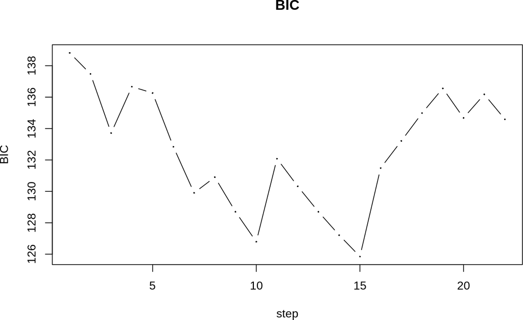

```r
plot(fit, xvar = "step", type = "bic")
```

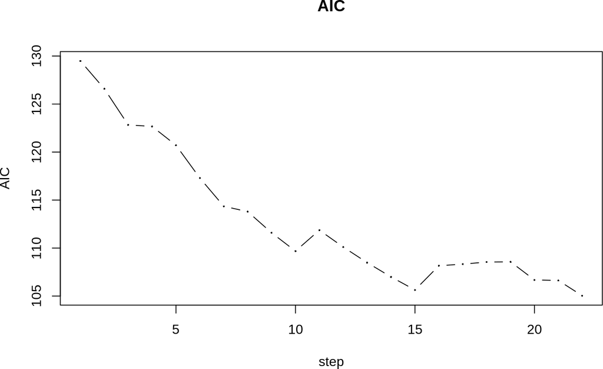

```r
plot(fit, xvar = "step", type = "aic")
```

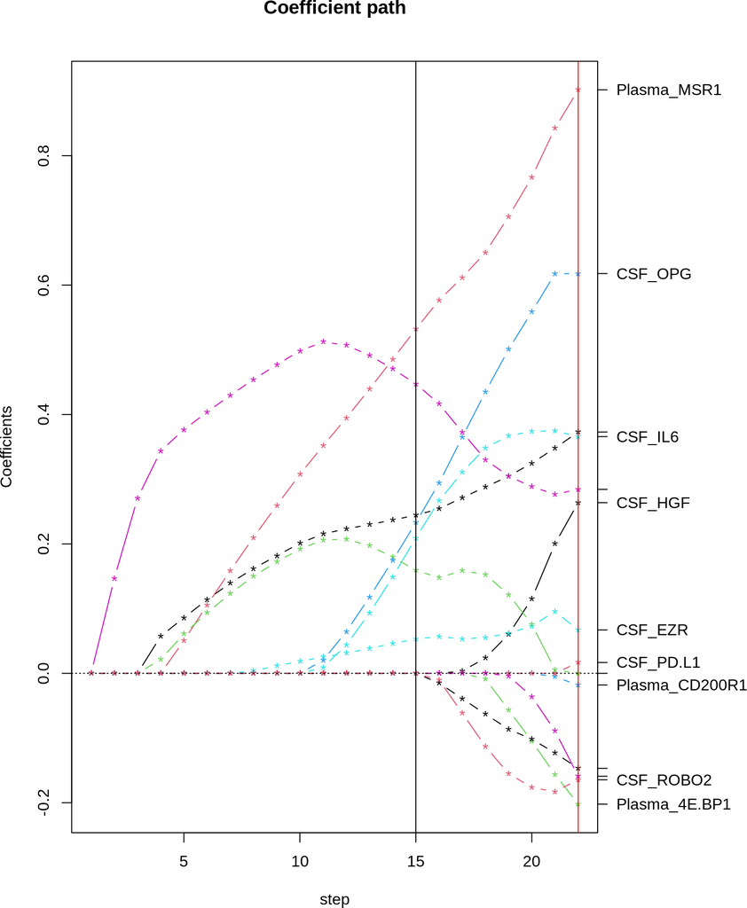

```r
par(mai=c(1.02,0.82,0.82,1.62))
plot(fit, xvar = "step", type = "coefficients")
abline(v =select.glmnetcr(fit) )
abline(v =select.glmnetcr(fit,which="AIC") , col='red' )
```

```r
pdf("plots/top_PlasmaCSFprot_vs_SeverityIndex_CoefficientPath_OrdinalBackward.pdf", width = 10, height = 9)
par(mai=c(1.02,0.82,0.82,1.62))
plot(fit, xvar = "step", type = "coefficients")
abline(v =select.glmnetcr(fit) )
abline(v =select.glmnetcr(fit,which="AIC") , col='red' )
dev.off()
```

Extract the step with minimal BIC

```r
BIC.step <- select.glmnetcr(fit)
print(paste('best BIC step',BIC.step))
```

```
## [1] "best BIC step 15"
```

```r
print(paste('    lambda',fit$lambda[BIC.step]))
```

```
## [1] "    lambda 0.0294070087858323"
```

```r
print(paste('    %dev  ',fit$dev.ratio[BIC.step]))
```

```
## [1] "    %dev   0.463344379241868"
```

extract non-zero coefficients for best BIC

```r
ord_bckwd_param = nonzero.glmnetcr(fit, s = BIC.step)$beta
ord_bckwd_param
```

```
##    Plasma_IL8   Plasma_MSR1       CSF_IL6       CSF_IL8 CSF_TNFRSF12A
##    0.15384296    0.92990436    0.08617638    0.26391349    0.15702623
##       CSF_OPG       CSF_EZR           cp1           cp2           cp3
##    0.22328702    0.04319651    4.17354629    0.63367170    0.69693592
##           cp4           cp5           cp6
##   -0.76824471    0.75269593   -0.76544553
```

```r
## extract AIC,BIC,predictedclass and fitted proba for a designed step
hat<-fitted(fit, s = BIC.step)
names(hat)
```

```
## [1] "BIC"   "AIC"   "class" "probs"
```

```r
## reordering the levels of class, which are character
table(as.numeric(hat$class), as.numeric(as.character(y)))
```

```
##
##       2  4  5  6  8  9 10
##   2   4  0  0  0  0  0  0
##   4   3 13  1  2  0  3  0
##   9   0  0  1  1  1  3  2
##   10  0  0  0  0  0  0  1
```

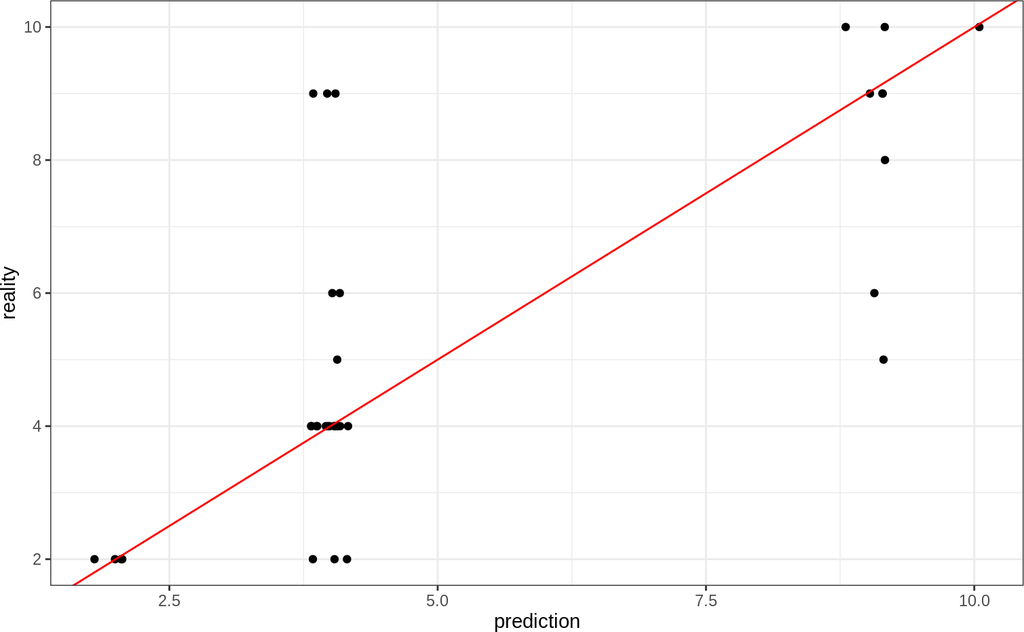

```r
# heatmap(table(factor(as.numeric(hat$class), levels= levels(y)), y),
#         Rowv=FALSE, Colv=FALSE)

plot.data <- as.data.frame(cbind(reality=as.numeric(as.character(y)), prediction=as.numeric(hat$class)))

ggplot(plot.data, aes(x=prediction, y=reality))+
  theme_bw()+
  geom_jitter(width = 0.2, height = 0)+
  geom_abline(intercept = 0, color="red")
```

```r
## misclassification error:
# mean(factor( as.numeric(hat$class) , levels= levels(y)) != y)
```

```r
## misclassification error, not very adapted here
misError =  mean( as.numeric(hat$class) != as.numeric(as.character(y)))


ord_bckwd_RMSE = sqrt( mean( ( as.numeric(hat$class) - as.numeric(as.character(y)) )**2 ) )

print(paste('backward ordinal regression model RMSE', ord_bckwd_RMSE))
```

```
## [1] "backward ordinal regression model RMSE 1.88224789622864"
```

## 3.2 Ordinal regression **forward** method

```r
fit <- glmnetcr(x, y, method = "forward")
print(fit)
```

```
##
## Call:  glmnet(x = glmnet.data$x, y = glmnet.data$y, family = "binomial",      weights = glmnet.data$weights, offset = offset, alpha = alpha,      nlambda = nlambda, lambda.min.ratio = lambda.min.ratio, lambda = lambda,      standardize = standardize, thresh = thresh, dfmax = dfmax,      pmax = pm…
##
##       Df   %Dev  Lambda
##  [1,]  6 0.1143 0.13410
##  [2,]  8 0.1470 0.12220
##  [3,]  8 0.1768 0.11140
##  [4,]  8 0.2025 0.10150
##  [5,]  9 0.2249 0.09245
##  [6,]  9 0.2463 0.08424
##  [7,]  9 0.2648 0.07676
##  [8,]  9 0.2810 0.06994
##  [9,] 10 0.2954 0.06372
## [10,] 10 0.3085 0.05806
## [11,] 10 0.3199 0.05291
## [12,] 10 0.3301 0.04821
## [13,] 15 0.3411 0.04392
## [14,] 15 0.3597 0.04002
## [15,] 15 0.3773 0.03647
## [16,] 16 0.3953 0.03323
## [17,] 17 0.4135 0.03027
## [18,] 17 0.4303 0.02758
## [19,] 17 0.4484 0.02513
## [20,] 15 0.4658 0.02290
## [21,] 16 0.4816 0.02087
```

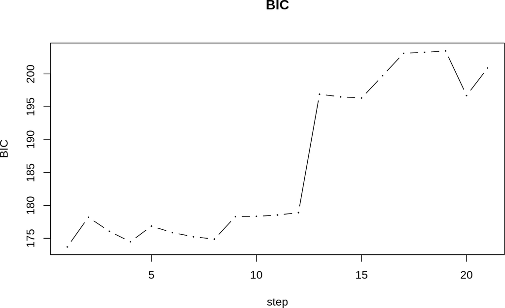

```r
plot(fit, xvar = "step", type = "bic")
```

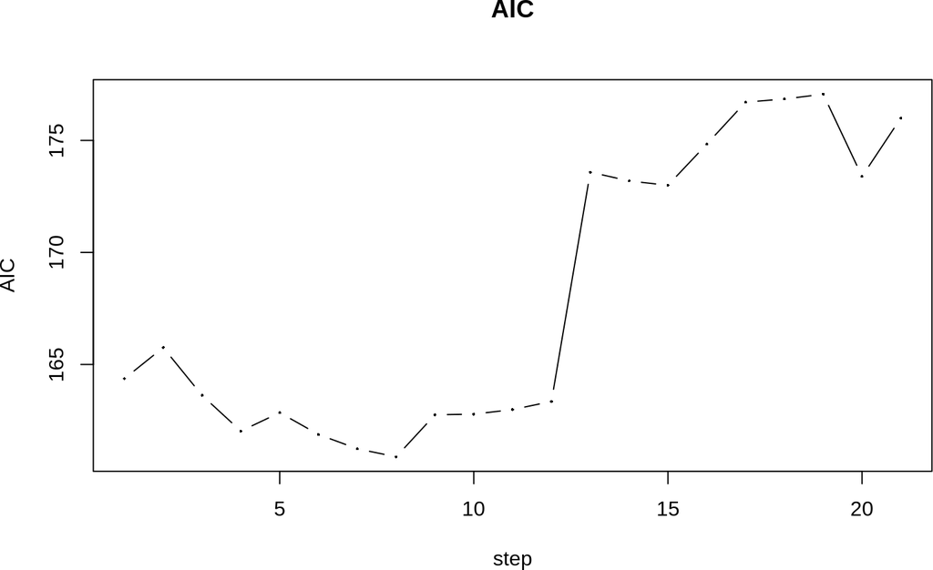

```r
plot(fit, xvar = "step", type = "aic")
```

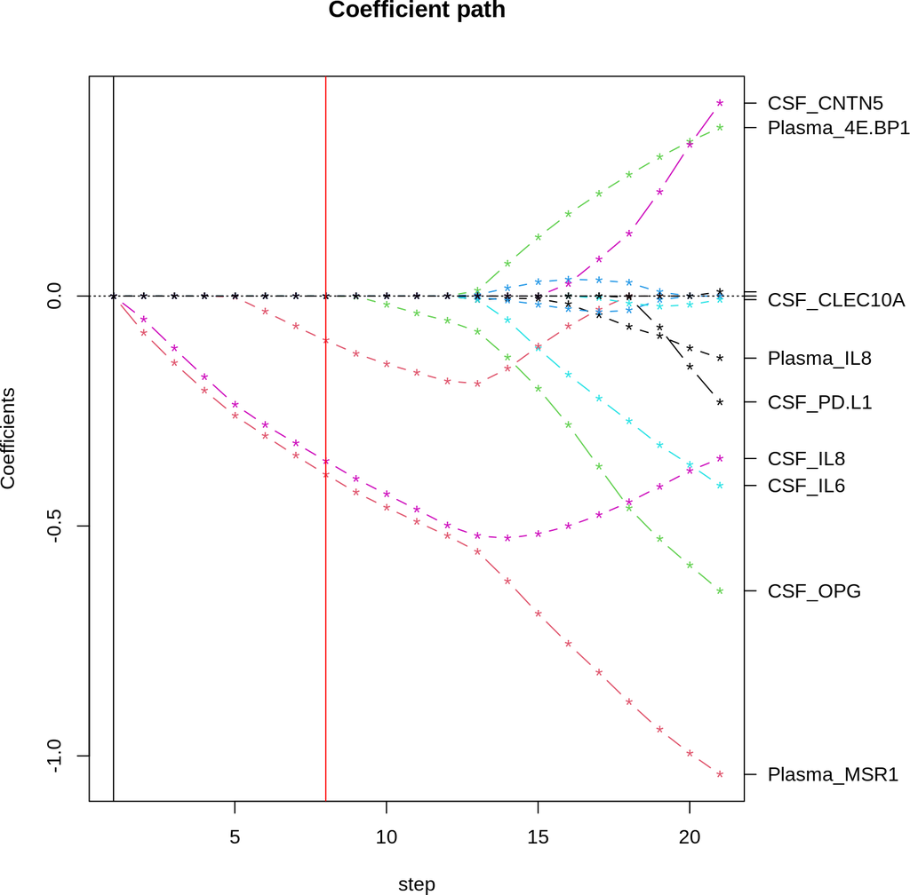

```r
par(mai=c(1.02,0.82,0.82,1.62))
plot(fit, xvar = "step", type = "coefficients")
abline(v =select.glmnetcr(fit) )
abline(v =select.glmnetcr(fit,which='AIC') , col='red' )
```

```r
pdf("plots/top_PlasmaCSFprot_vs_SeverityIndex_CoefficientPath_OrdinalForward.pdf", width = 10, height = 9)
par(mai=c(1.02,0.82,0.82,1.62))
plot(fit, xvar = "step", type = "coefficients")
abline(v =select.glmnetcr(fit) )
abline(v =select.glmnetcr(fit,which='AIC') , col='red' )
dev.off()
```

```r
BIC.step <- select.glmnetcr(fit)
BIC.step
```

```
## s0
##  1
```

extract non-zero coefficients for best BIC

```r
##
nonzero.glmnetcr(fit, s = BIC.step)
```

```
## $a0
##         s0
## -0.9257013
##
## $beta
##        cp1        cp2        cp3        cp4        cp5        cp6
## -0.4611233  0.7823551 -0.9443086 -0.2778662 -1.2672978  1.6176809
```

This has just no parameters… Let go with the AIC

```r
AIC.step <- select.glmnetcr(fit , which='AIC')

print(paste('best AIC step',AIC.step))
```

```
## [1] "best AIC step 8"
```

```r
print(paste('    lambda',fit$lambda[AIC.step]))
```

```
## [1] "    lambda 0.0699378155649377"
```

```r
print(paste('    %dev  ',fit$dev.ratio[AIC.step]))
```

```
## [1] "    %dev   0.280964807076406"
```

```r
ord_forwd_param = nonzero.glmnetcr(fit, s = AIC.step)$beta
ord_forwd_param
```

```
##   Plasma_MSR1       CSF_IL8 CSF_TNFRSF12A           cp1           cp2
##   -0.67781270   -0.21140062   -0.09531604   -1.14419786    0.43134376
##           cp3           cp4           cp5           cp6
##   -0.90465592   -0.20412215   -1.13375249    1.85950642
```

```r
## extract AIC,BIC,predictedclass and fitted proba for a designed step
hat<-fitted(fit, s = AIC.step)

## reordering the levels of class, which are character
table(factor(as.numeric(hat$class), levels= levels(y)), y)
```

```
##     y
##       2  4  5  6  8  9 10
##   2   1  0  0  0  0  0  0
##   4   6 13  1  2  1  5  1
##   5   0  0  0  0  0  0  0
##   6   0  0  0  0  0  0  0
##   8   0  0  0  0  0  0  0
##   9   0  0  1  1  0  1  1
##   10  0  0  0  0  0  0  1
```

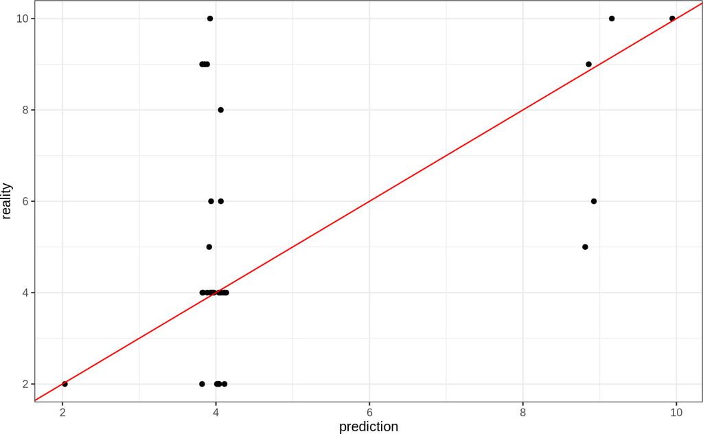

```r
plot.data <- as.data.frame(cbind(reality=as.numeric(as.character(y)), prediction=as.numeric(hat$class)))

ggplot(plot.data, aes(x=prediction, y=reality))+
  theme_bw()+
  geom_jitter(width = 0.2, height = 0)+
  geom_abline(intercept = 0, color="red")
```

```r
## misclassification error, not very adapted here
misError =  mean( as.numeric(hat$class) != as.numeric(as.character(y)))


ord_forwd_RMSE = sqrt( mean( ( as.numeric(hat$class) - as.numeric(as.character(y)) )**2 ) )

print(paste('backward ordinal regression model RMSE', ord_forwd_RMSE))
```

```
## [1] "backward ordinal regression model RMSE 2.5967012040004"
```

**So far,** using the appropriate ordinal regression with an L1 regularization, we get fairly mild fits.

The backward model performs better, but with still quite a bit of error (RMSE=1.9)

Interestingly, the forward model, while it’s AIC suggest a higher level of regularization, mostly puts forward molecules also retained in the backward model:

Intersect between forward and backward model retain molecules:

```r
intersect( names(ord_bckwd_param) , names(ord_forwd_param)  )
```

```
## [1] "Plasma_MSR1"   "CSF_IL8"       "CSF_TNFRSF12A" "cp1"
## [5] "cp2"           "cp3"           "cp4"           "cp5"
## [9] "cp6"
```

Molecules in backward model only :

```r
setdiff( names(ord_bckwd_param) , names(ord_forwd_param)  )
```

```
## [1] "Plasma_IL8" "CSF_IL6"    "CSF_OPG"    "CSF_EZR"
```

Molecules in forward model only :

```r
setdiff( names(ord_forwd_param) , names(ord_bckwd_param)  )
```

```
## character(0)
```

# 4 Simple linear regression

In order to complement the analysis with the ordinal regression model, we will perform an analysis with the, simpler, linear regression, but still with some regularization and also with cross-validation for model selection.

**note to self:** Contrary to the previous case, this model is not, a priori, appropriate for our data, so we will have to check the models assumptions before we can make our conclusion.

```r
# trying simple linear model

X=x

numericY = as.numeric(as.character(y))
```

linear model with L1 norm (`alpha=1`) and , 10-fold cross-validation (`nfolds=10`)

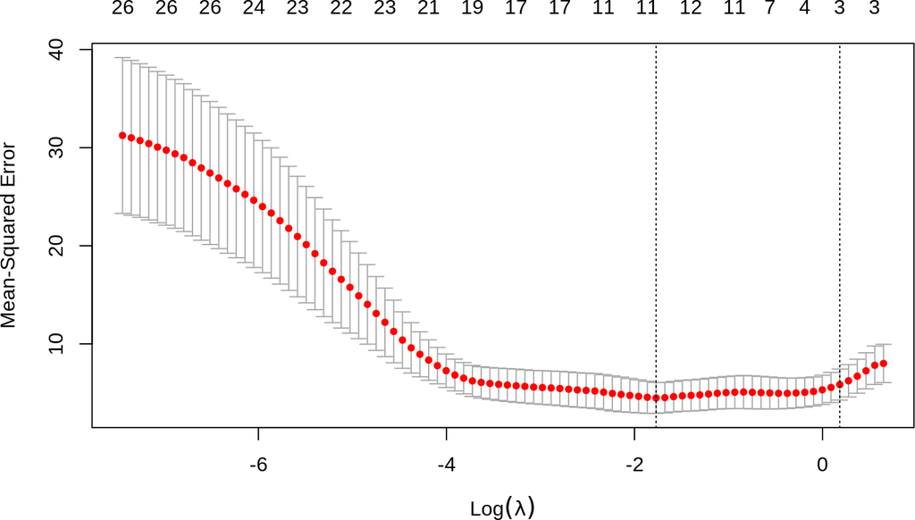

```r
set.seed(36)
nFolds <- 10
foldid <- sample(rep(seq(nFolds), length.out = nrow(X)))
cvfit <- cv.glmnet(as.matrix(X),
                   numericY ,
                   alpha=1, nfolds = nFolds, foldid = foldid)

plot(cvfit)
```

* x-axis : strength of regularization * y=axis : Mean squared Error : fitting metric we want to minimize

The error bars around the MSE in that zone are pleasantly small.

the leftmost line is the value of λ that gives minimum mean cross-validated error, while the rightmost one is the value of λ that gives the most regularized model such that the cross-validated error is within one standard error of the minimum.

```r
cvfit$lambda.min
```

```
## [1] 0.1702827
```

Now, let’s grab the *best* model and see if it is appropriate

```
##    lambda.min
##  Min.   :-2.97762
##  1st Qu.:-0.74077
##  Median : 0.09323
##  Mean   : 0.00000
##  3rd Qu.: 0.78151
##  Max.   : 2.04386
```

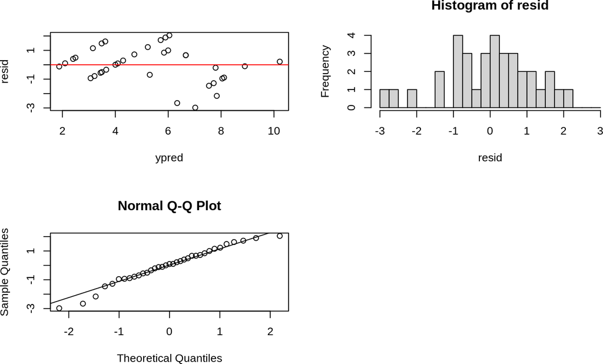

```r
ypred = predict(cvfit, newx = as.matrix(x), s = "lambda.min")

resid = ypred - numericY

par(mfrow=c(2,2))

## checking for gross heteroskedascticity
plot(ypred , resid)
abline(h=0,col='red')

# visualizing  residuals distribution
hist(resid, breaks= seq(-3,3,by=0.25))

# checking normality of residuals
qqnorm(resid)
qqline(resid)

print(summary(resid))
```

The residuals seem to follow a something close to a normal distribution centered on 0 and there is no sign of heteroskedascticity, however there may be a sort of skew (over predict low scores, under predict small scores)…

This is correct, we can actually interpret these results!

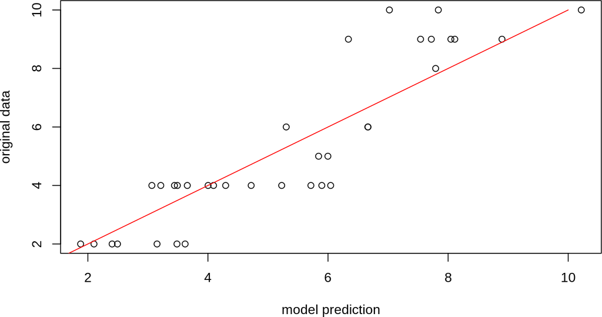

```r
plot(ypred, numericY , xlab='model prediction' , ylab='original data')
lines(c(0,10),c(0,10),col='red')
```

```r
Rsq = cor( ypred , numericY  )**2


RMSE = sqrt( mean( (ypred - numericY)**2 ) )


print('cross validated gaussian linear model ')
```

```
## [1] "cross validated gaussian linear model "
```

```r
print(paste('  R-squared' , Rsq))
```

```
## [1] "  R-squared 0.814505587338497"
```

```r
print(paste('  RMSE' , RMSE))
```

```
## [1] "  RMSE 1.20550092444488"
```

Overall, that looks like an OK fit. The RMSE is still quite high.

Let’s look at the molecules which were retained for this model

```r
COEF = coef(cvfit, s = "lambda.min")
nonNull.COEF = COEF[ which( !(COEF==0) ) ]
names( nonNull.COEF ) = row.names( COEF )[ which( !(COEF==0) ) ]
nonNull.COEF
```

```
##   (Intercept)    Plasma_IL8   Plasma_MSR1 Plasma_4E.BP1       CSF_IL6
## -14.207905976   0.117632643   1.924947571  -0.300234455   0.031915293
##       CSF_IL8     CSF_PD.L1 CSF_TNFRSF12A       CSF_OPG       CSF_EZR
##   0.076722231   0.609794980   0.001449532   0.638136341   0.083980481
##     CSF_BMP.4   CSF_CLEC10A     CSF_ROBO2
##  -0.025434751   0.774218810  -0.548431904
```

That is a lot of molecules. Between that and the super good result, we should be expected some overfitting

Molecules which were also retained in the backward ordinal regression:

```r
intersect( names( ord_bckwd_param ) , names(nonNull.COEF))
```

```
## [1] "Plasma_IL8"    "Plasma_MSR1"   "CSF_IL6"       "CSF_IL8"
## [5] "CSF_TNFRSF12A" "CSF_OPG"       "CSF_EZR"
```

That’s not much but it is interesting

Only in linear model:

```r
setdiff(names(nonNull.COEF),  names( ord_bckwd_param ) )
```

```
## [1] "(Intercept)"   "Plasma_4E.BP1" "CSF_PD.L1"     "CSF_BMP.4"
## [5] "CSF_CLEC10A"   "CSF_ROBO2"
```

Additionally, here are the molecules for the most regularized model such that the cross-validated error is within one standard error of the minimum.

```r
COEF = coef(cvfit, s = "lambda.1se")
nonNull.COEF.1se = COEF[ which( !(COEF==0) ) ]
names( nonNull.COEF.1se ) = row.names( COEF )[ which( !(COEF==0) ) ]
nonNull.COEF.1se
```

```
##   (Intercept)   Plasma_MSR1       CSF_IL8 CSF_TNFRSF12A
##    -1.4314480     0.5616743     0.1619705     0.3431248
```

In common between the 2 different linear models:

```r
intersect( names( nonNull.COEF.1se )  , names(nonNull.COEF))
```

```
## [1] "(Intercept)"   "Plasma_MSR1"   "CSF_IL8"       "CSF_TNFRSF12A"
```

```r
fractionR = ( length(intersect( names( nonNull.COEF.1se )  , names(nonNull.COEF))) -1)/(length(nonNull.COEF.1se)-1)
print( paste('fraction of molecules in heavily regularized linear model also in best fit:',fractionR)  )
```

```
## [1] "fraction of molecules in heavily regularized linear model also in best fit: 1"
```

That’s quite nice.

Let’s see how this intersect with the ordinal regression:

```r
intersect( names( ord_bckwd_param ) , names(nonNull.COEF.1se))
```

```
## [1] "Plasma_MSR1"   "CSF_IL8"       "CSF_TNFRSF12A"
```

Same parameter intersect.

Let’s evaluate this more heavily regularized model:

```
##    lambda.1se
##  Min.   :-3.9965
##  1st Qu.:-1.9968
##  Median : 0.7083
##  Mean   : 0.0000
##  3rd Qu.: 1.4818
##  Max.   : 3.1655
```

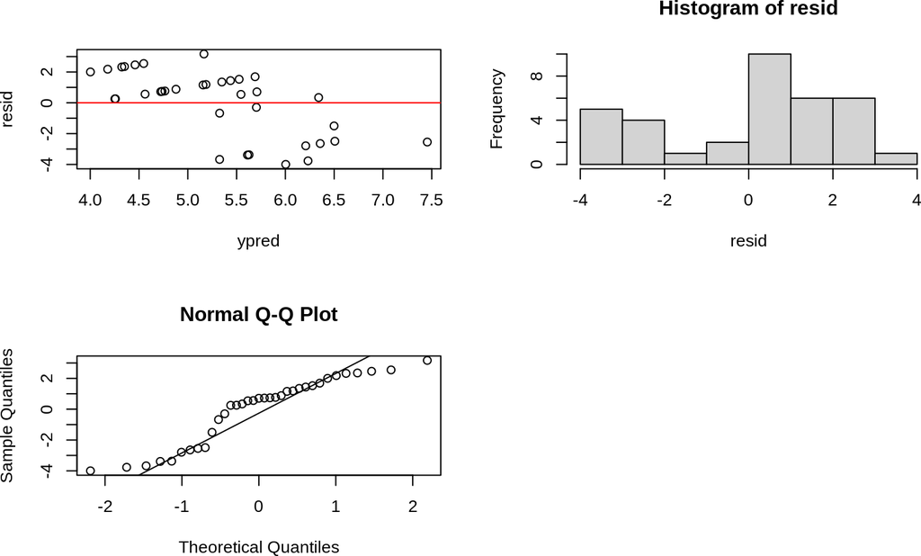

```r
ypred = predict(cvfit, newx = as.matrix(x), s = "lambda.1se")

resid = ypred - numericY

par(mfrow=c(2,2))

## checking for gross heteroskedascticity
plot(ypred , resid)
abline(h=0,col='red')

# visualizing  residuals distribution
hist(resid)#, breaks= seq(-1.5,1.5,by=0.25))

# checking normality of residuals
qqnorm(resid)
qqline(resid)

print(summary(resid))
```

Conclusions similar to the best model, but the general feel of this is degraded. Maybe this is not the most appropriate model there.

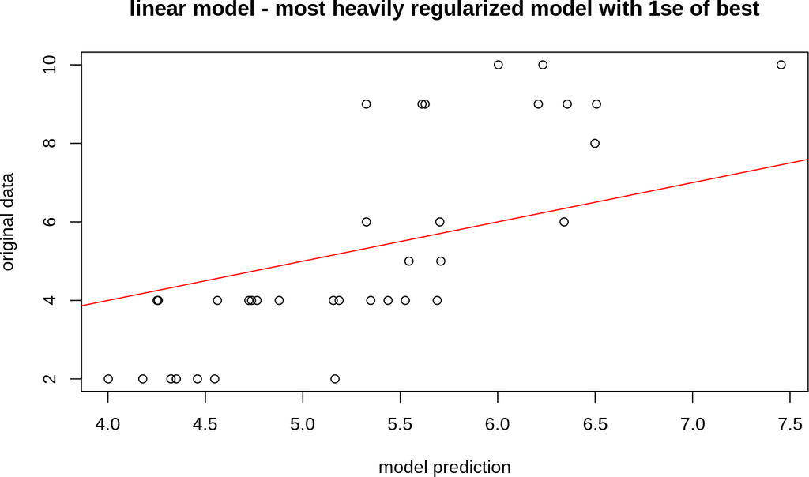

```r
plot(ypred, numericY , xlab='model prediction' , ylab='original data', main='linear model - most heavily regularized model with 1se of best')
lines(c(0,10),c(0,10),col='red')
```

```r
Rsq = cor( ypred , numericY  )**2
RMSE = sqrt( mean( (ypred - numericY)**2 ) )

print('cross validated gaussian linear model ')
```

```
## [1] "cross validated gaussian linear model "
```

```r
print(paste('  R-squared' , Rsq))
```

```
## [1] "  R-squared 0.658572645846666"
```

```r
print(paste('  RMSE' , RMSE))
```

```
## [1] "  RMSE 2.10187823364355"
```

### 4.0.1 plotting gaussian linear models evolution

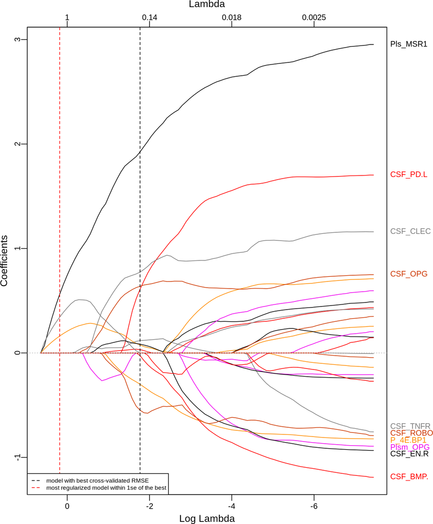

```r
linfit <- glmnet( as.matrix(X),
                   numericY ,
                   alpha=1)


par(mar = c(3,5,2,1))

plot_glmnet(linfit)
abline( v = log(cvfit$lambda.min ) ,  lty=2 )
abline( v = log(cvfit$lambda.1se ) , col = 'red' , lty=2 )

legend( 'bottomleft' ,
        c( 'model with best cross-validated RMSE' , 'most regularized model within 1se of the best' ) ,
        col=c('black','red') ,
        lty=2 , cex = 0.6)
```

```r
pdf("plots/top_PlasmaCSFprot_vs_SeverityIndex_CoefficientPath_GaussianLM.pdf", width = 10)
par(mar = c(3,5,2,1.5))

plot_glmnet(linfit)
abline( v = log(cvfit$lambda.min ) ,  lty=2 )
abline( v = log(cvfit$lambda.1se ) , col = 'red' , lty=2 )

legend( 'bottomleft' ,
        c( 'model with best cross-validated RMSE' , 'most regularized model within 1se of the best' ) ,
        col=c('black','red') ,
        lty=2 , cex = 0.6)
dev.off()
```

fancy interactive version:

```r
coefpath(linfit)
```

[interactive chart not shown]

## 4.1 recap of the molecules selected by each model

ordinal backward

```r
ord_bckwd_param[ 1:(length(ord_bckwd_param)-6) ] # exclude last 6 which are the thresholds
```

```
##    Plasma_IL8   Plasma_MSR1       CSF_IL6       CSF_IL8 CSF_TNFRSF12A
##    0.15384296    0.92990436    0.08617638    0.26391349    0.15702623
##       CSF_OPG       CSF_EZR
##    0.22328702    0.04319651
```

ordinal forward

```r
ord_forwd_param[ 1:(length(ord_forwd_param)-6) ] # exclude last 6 which are the thresholds
```

```
##   Plasma_MSR1       CSF_IL8 CSF_TNFRSF12A
##   -0.67781270   -0.21140062   -0.09531604
```

gaussian linear model with best RMSE

```r
nonNull.COEF[2:length(nonNull.COEF)]
```

```
##    Plasma_IL8   Plasma_MSR1 Plasma_4E.BP1       CSF_IL6       CSF_IL8
##   0.117632643   1.924947571  -0.300234455   0.031915293   0.076722231
##     CSF_PD.L1 CSF_TNFRSF12A       CSF_OPG       CSF_EZR     CSF_BMP.4
##   0.609794980   0.001449532   0.638136341   0.083980481  -0.025434751
##   CSF_CLEC10A     CSF_ROBO2
##   0.774218810  -0.548431904
```

most regularized gaussian linear model within 1se of the best model

```r
nonNull.COEF.1se[2:length(nonNull.COEF.1se)]
```

```
##   Plasma_MSR1       CSF_IL8 CSF_TNFRSF12A
##     0.5616743     0.1619705     0.3431248
```

**Note for figure finalization : molecule OPG should be renamed TNFRSF11B**

### 4.1.1 Venn diagram

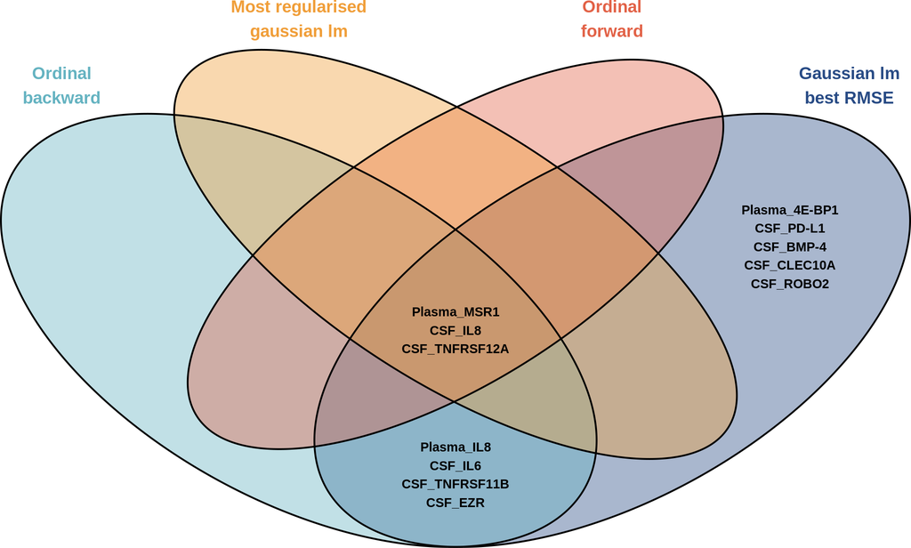

```r
venn.list=list()
venn.list$"Ordinal\nbackward" <- names(ord_bckwd_param[ 1:(length(ord_bckwd_param)-6) ])
venn.list$"Gaussian lm\nbest RMSE" <- names(nonNull.COEF[2:length(nonNull.COEF)])
venn.list$"Most regularised\ngaussian lm" <- names(nonNull.COEF.1se[2:length(nonNull.COEF.1se)])
venn.list$"Ordinal\nforward" <- names(ord_forwd_param[ 1:(length(ord_forwd_param)-6) ])

# change . in - for all the proteins
venn.list <- lapply(X = venn.list, FUN = function(t) gsub(pattern = ".", replacement = "-", x = t, fixed = TRUE))
# rename OPG
venn.list <- lapply(X = venn.list, FUN = function(t) gsub(pattern = "OPG", replacement = "TNFRSF11B", x = t, fixed = TRUE))

# Generate plot
v <- venn.diagram(venn.list,
                  filename=NULL,

                  # circles color
                  fill = c("#65B3C1", "#284B85", "#F09E39", "#E26247"),
                  alpha = 0.4,

                  # protein labels
                  cex = 0.9,
                  fontface = "bold",
                  fontfamily = "Arial",

                  # circles titles
                  cat.col = c("#65B3C1", "#284B85", "#F09E39", "#E26247"),
                  cat.fontfamily = "Arial",
                  cat.fontface = "bold",
                  cat.cex = 1.2)

# Calculate overlap site
overlaps <- calculate.overlap(venn.list)
overlaps <- overlaps[str_sort(names(overlaps), numeric = TRUE)] # sort base on numeric value

# Apply name to global variable
# Index of venn diagram start at calculate.overlaps + 8. You have to find the index value by yourself for (3,5,6,7,.. venn)
walk2(seq(overlaps) +8, seq(overlaps),
      function(x,y) {v[[x]]$label <<- paste0(overlaps[[y]], collapse = "\n")})

grid.draw(v)
```

```r
library(Cairo)
CairoPDF("plots/VennDiagram_top_PlasmaCSFprot_SeverityIndex.pdf", width = 11, height = 9)
grid.draw(v)
dev.off()
```